# EDA Visualization with Matplotlib and Seaborn

## Histogram

Is a distribution of data by forming bins along the range of the data and then drawing bars to show the number of observations that fall in each bin.

```python
flowers['sepal length']
```

```
0      5.1
1      4.9
2      4.7
3      4.6
4      5.0
      ...
145    6.7
146    6.3
147    6.5
148    6.2
149    5.9
Name: sepal length, Length: 150, dtype: float64
```

```python
flowers.describe()['sepal length']
```

```
count    150.000000
mean       5.843333
std        0.828066
min        4.300000
25%        5.100000
50%        5.800000
75%        6.400000
max        7.900000
Name: sepal length, dtype: float64
```

```python
flowers.describe()['petal width']
```

```
count    150.000000
mean       1.199333
std        0.762238
min        0.100000
25%        0.300000
50%        1.300000
75%        1.800000
max        2.500000
Name: petal width, dtype: float64
```

```python
flowers.describe()
```

|  | sepal length | sepal width | petal length | petal width |
| --- | --- | --- | --- | --- |
| count | 150.000000 | 150.000000 | 150.000000 | 150.000000 |
| mean | 5.843333 | 3.057333 | 3.758000 | 1.199333 |
| std | 0.828066 | 0.435866 | 1.765298 | 0.762238 |
| min | 4.300000 | 2.000000 | 1.000000 | 0.100000 |
| 25% | 5.100000 | 2.800000 | 1.600000 | 0.300000 |
| 50% | 5.800000 | 3.000000 | 4.350000 | 1.300000 |
| 75% | 6.400000 | 3.300000 | 5.100000 | 1.800000 |
| max | 7.900000 | 4.400000 | 6.900000 | 2.500000 |

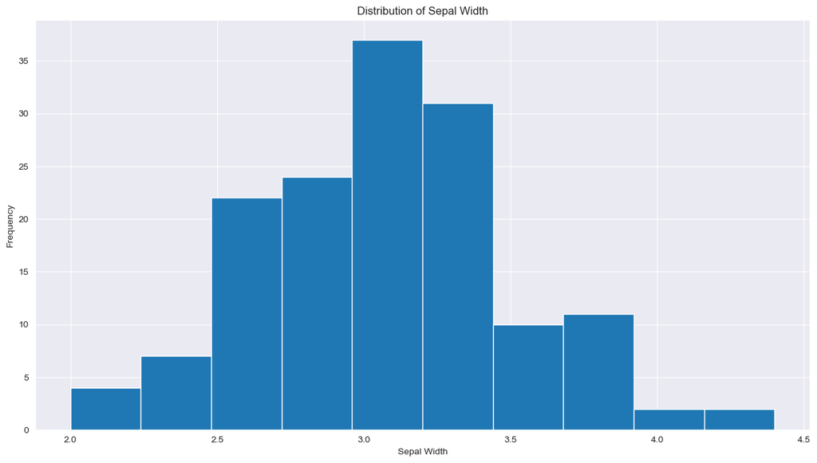

```python
plt.title('Distribution of Sepal Width')

plt.hist(flowers['sepal width'])
plt.xlabel('Sepal Width')
plt.ylabel('Frequency');
```

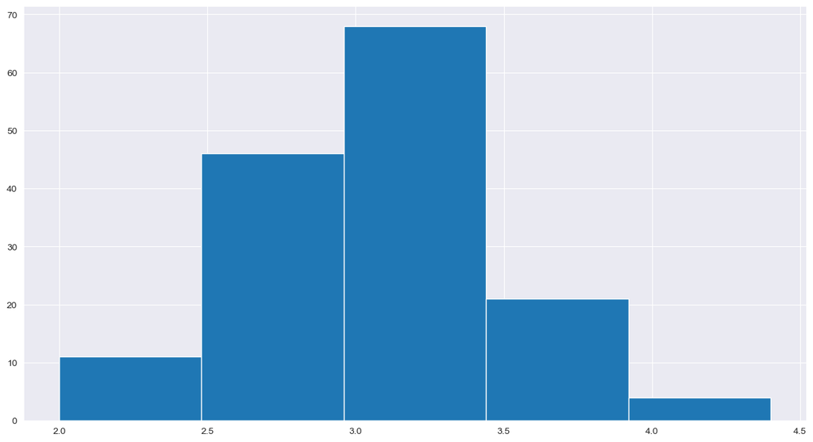

```python
#Specifying the number of bins

plt.hist(flowers['sepal width'], bins = 5);
```

Specifying the points to which bins should be created. For bins to be created you need to import numpy

```python
import numpy as np
np.arange(2, 5, 0.25)
```

```
array([2.  , 2.25, 2.5 , 2.75, 3.  , 3.25, 3.5 , 3.75, 4.  , 4.25, 4.5 ,
       4.75])
```

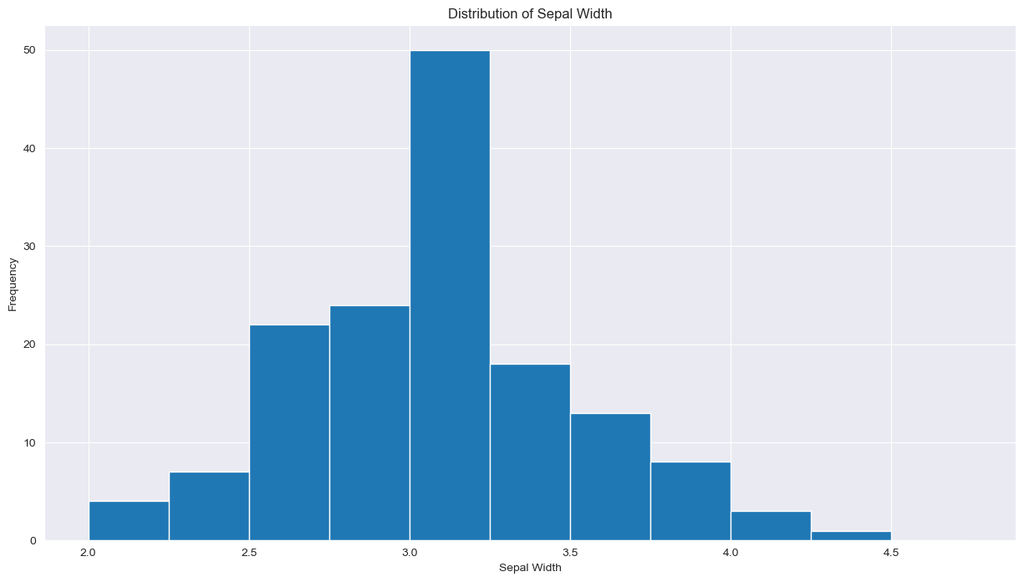

```python
plt.hist(flowers['sepal width'], bins=np.arange(2, 5, 0.25))
plt.xlabel('Sepal Width')
plt.ylabel('Frequency')
plt.title('Distribution of Sepal Width');
```

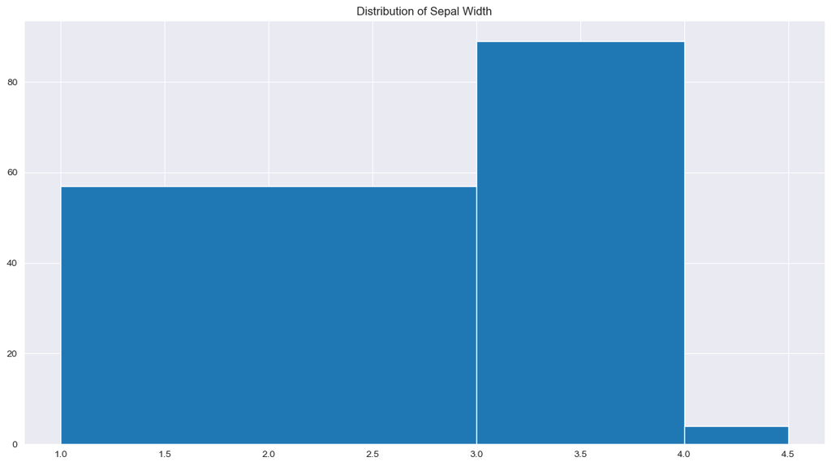

```python
plt.hist(flowers['sepal width'], bins=[1, 3, 4, 4.5])
#plt.xlabel('Sepal Width')
#plt.ylabel('Frequency')
plt.title('Distribution of Sepal Width');
#plt.show()

#the bin of unequal sizes starting from 1 - 3 and is of lenght 2. then 3-4 thats
#bin lenght of 1. and the last and is 1/2 ihalf length
```

### Drawing multiple histogram in a single chart

```python
setosa = flowers[flowers.species == 'setosa']
versicolor = flowers[flowers.species == 'versicolor']
virginica = flowers[flowers.species == 'virginica']
```

```python
flowers.species
```

```
0         setosa
1         setosa
2         setosa
3         setosa
4         setosa
         ...
145    virginica
146    virginica
147    virginica
148    virginica
149    virginica
Name: species, Length: 150, dtype: object
```

Drawing histogram ontop of each other. To do that you set lower opacity for each of the histogram.

```python
setosa = flowers[flowers.species == 'setosa']
versicolor = flowers[flowers.species == 'versicolor']
virginica = flowers[flowers.species == 'virginica']
```

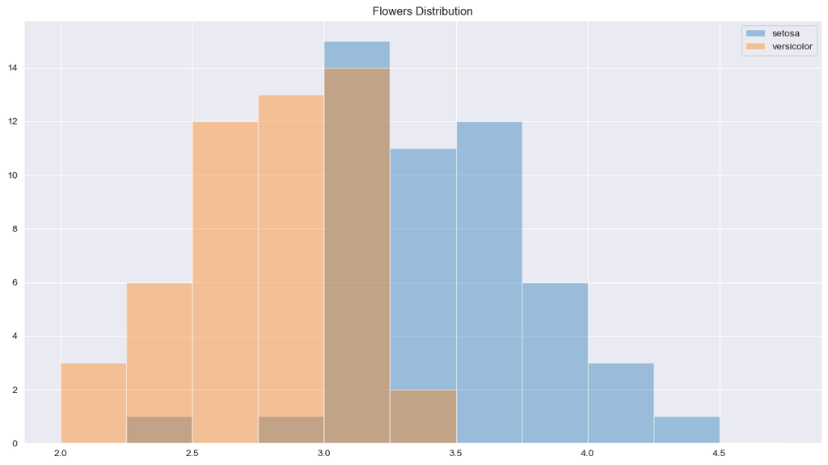

```python
plt.hist(setosa['sepal width'],alpha=0.4, bins= np.arange (2, 5, 0.25))
plt.hist(versicolor['sepal width'], alpha=0.4, bins=np.arange (2, 5, 0.25));
plt.title('Flowers Distribution');
plt.legend(['setosa','versicolor' ]);
```

### Stacking histogram ontop of one another

To do this you pass in the columns you want to plot as a list.

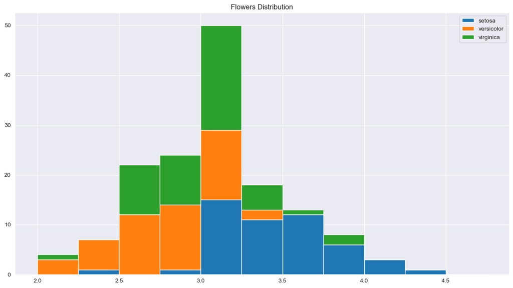

```python
plt.title('Flowers Distribution');
plt.hist([setosa['sepal width'],versicolor['sepal width'], virginica['sepal width']],
       bins = np.arange(2, 5, 0.25),
       stacked = True);
plt.legend(['setosa', 'versicolor', 'virginica']);
```

### Bar Chart

It is similar to line line chart.

```python
import seaborn as sns
```

```python
years = range(2000, 2006)
apples = [0.35, 0.6, 0.9, 0.8, 0.65, 0.8]
oranges = [0.4, 0.8, 0.9, 0.7, 0.6, 0.8]
```

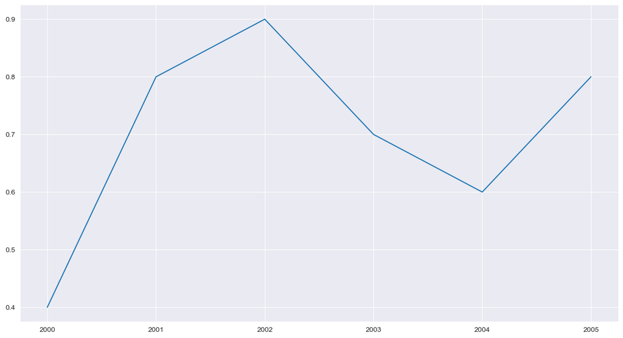

```python
#plt.plot(years, apples),
plt.plot(years, oranges);
```

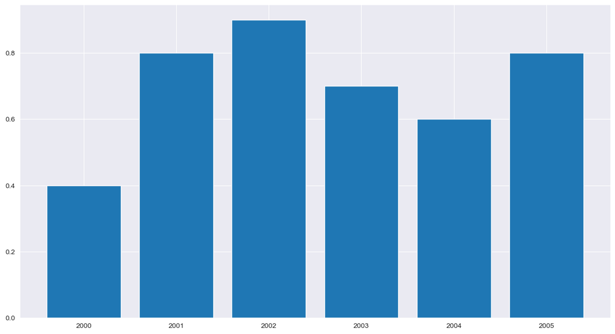

```python
plt.bar(years,(oranges));
```

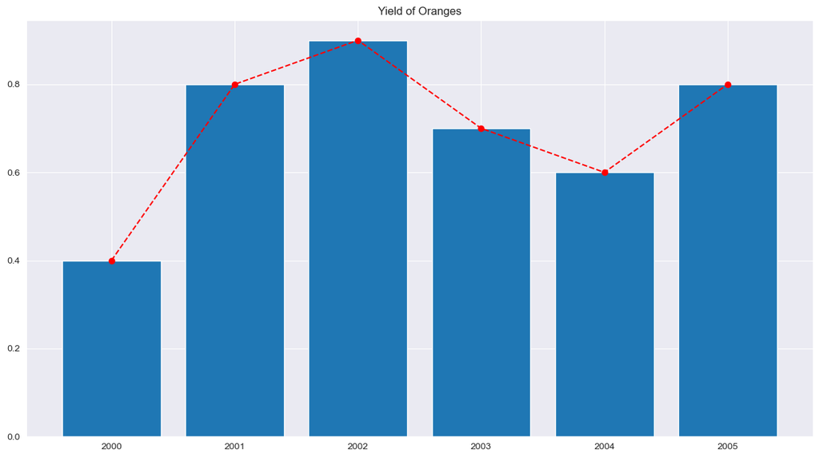

```python
plt.bar(years,(oranges));
plt.plot(years, oranges,  'o--r');
plt.title('Yield of Oranges');
```

How to stacked bars on top of one another. use the bottom argument, to achieve this plt.bar

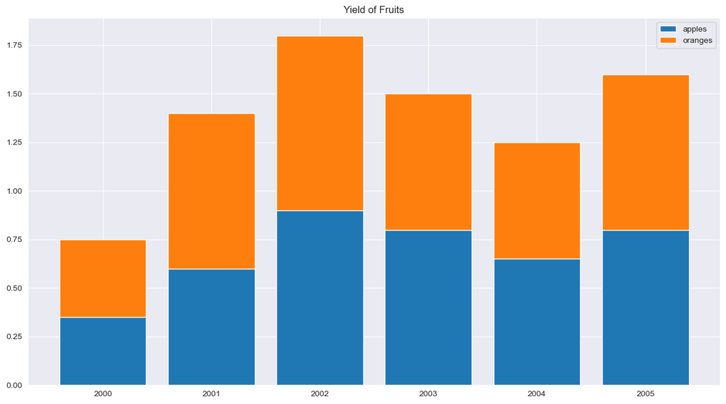

```python
plt.bar(years, apples);
plt.bar(years, oranges, bottom = apples);
plt.title('Yield of Fruits');
plt.legend(['apples', 'oranges']);
```

Dataset that contains information about customers

```python
tips = sns.load_dataset('tips')
tips
```

|  | total_bill | tip | sex | smoker | day | time | size |
| --- | --- | --- | --- | --- | --- | --- | --- |
| 0 | 16.99 | 1.01 | Female | No | Sun | Dinner | 2 |
| 1 | 10.34 | 1.66 | Male | No | Sun | Dinner | 3 |
| 2 | 21.01 | 3.50 | Male | No | Sun | Dinner | 3 |
| 3 | 23.68 | 3.31 | Male | No | Sun | Dinner | 2 |
| 4 | 24.59 | 3.61 | Female | No | Sun | Dinner | 4 |
| ... | ... | ... | ... | ... | ... | ... | ... |
| 239 | 29.03 | 5.92 | Male | No | Sat | Dinner | 3 |
| 240 | 27.18 | 2.00 | Female | Yes | Sat | Dinner | 2 |
| 241 | 22.67 | 2.00 | Male | Yes | Sat | Dinner | 2 |
| 242 | 17.82 | 1.75 | Male | No | Sat | Dinner | 2 |
| 243 | 18.78 | 3.00 | Female | No | Thur | Dinner | 2 |

244 rows × 7 columns

```python
#Performing groupby with the data

avgbill = tips.groupby('day')[['total_bill']].mean()
avgbill
```

| day | total_bill |
| --- | --- |
| Thur | 17.682742 |
| Fri | 17.151579 |
| Sat | 20.441379 |
| Sun | 21.410000 |

```python
#Performing groupby with the data

tipz = tips.groupby('day')[['tip']].mean()
tipz
```

| day | tip |
| --- | --- |
| Thur | 2.771452 |
| Fri | 2.734737 |
| Sat | 2.993103 |
| Sun | 3.255132 |